# Convergence Concepts

Seoncheol Park

12/1/2019

# 확률변수의 수렴

(Proschan 2016)의 내용을 따라간다. 통계적 추론에서 가장 중요한 부분 중 하나는 추정량 $\hat{\theta}_{n}$에서 $n\rightarrow\infty$일 때 어떤 일이 일어나는지 살펴보는 것이다. 많은 다른 질문들을 생각해 볼 수 있다. 첫째로, $\hat{\theta}_{n}$이 $n\rightarrow\infty$일 때 진짜 모수 $\theta$에 “가까이” 가는가에 대해 생각해 볼 수 있다. 이 “가까이” 라는 개념을 세 가지 정도로 정의할 수 있다.

1. $\theta_{n}$이 $\theta$에 확률 1로 수렴한다.
2. 어떤 주어진 $\epsilon >0$에 대해 $\hat{\theta}_{n}$ 이 $\theta$와 $\epsilon$ 거리 이내에 위치할 확률이 1이다.
3. 기댓값 $|\hat{\theta}_{n}-\theta|^{p}$가 0으로 수렴한다.

이것들을 차례로 **거의 확실한 수렴(Almost sure convergence)**, **확률수렴(Convergence in probability)** 그리고 **Lp 수렴(Convergence in Lp)**이라고 부른다.

## 거의 확실한 수렴(Almost sure convergence)

$X_{1}, X_{2},\ldots$가 확률공간 $(\Omega, \mathcal{F}, P)$에서의 확률변수의 수열이라고 하자. 고정된 $\omega$에 대해 $X_{n}(\omega)=x_{n}, n=1,2,\ldots$은 숫자의 수열이라고 하자. 각 $\omega$에 대해 $X_{n}(\omega)$가 수렴할 수 있지만 극한 $X(\omega)$는 $\omega$에 따라 다를 수 있다. 예를 들면, $(\Omega, \mathcal{F}, P)=([0,1],\mathcal{B}_{[0,1]},\mu_{L})$ 이고

$$\begin{equation}
X_{n}(\omega)=\omega^{n}
\tag{1}
\end{equation}$$

이다. 그러면 $n\rightarrow \infty$일 때 $X_{n}(\omega) \rightarrow I(\omega=1)$이다. 그런데 어떤 $\omega$에 대해서는 $X_{n}(\omega)$는 극한이 없거나 무한대의 극한을 갖을 수 있다. 예를 들면 앞선 식 (1)을 다음과 같이 바꾸는 것이다.

$$\begin{equation}
X_{n}(\omega)=(-\omega)^{n}
\tag{2}
\end{equation}$$

그러면 $\omega < 1$일 때 $n\rightarrow 0$이나 $\omega=1$일 때는 극한이 존재하지 않는다.

식 (1)과 (2)에서의 행동이 다르다고 하더라도 $\{\omega=1\}$이 확률 0을 갖는다면 다른 행동을 무시할 수 있을 것이다. 이것을 확장시키면 확률 0인 집합들을 무시하는 것으로 이해할 수 있고, **거의 확실한 수렴(Almost sure convergence)**의 정의를 이끈다.

**Definition 1 (거의 확실한 수렴)** 1. 확률변수들 $X_{1}(\omega), X_{2}(\omega), \ldots$가 $X(\omega)$로 거의 확실한 수렴을 한다는 것은, 확률이 0인 집합을 제외한 나머지 부분에서 고정된 $\omega$에 대해 숫자들의 수열 $X_{n}(\omega)$가 $n\rightarrow\infty$함에 따라 $X(\omega)$로 수렴하는 것을 의미한다. 특별히 이것을 $X_{n}\rightarrow X a.s.$ 또는 $X_{n}\stackrel{a.s.}{\rightarrow}X$라고 쓴다.

2. 임의의 측도 공간 $(\Omega, \mathcal{F}, \mu)$위의 함수들 $f_{1}(\omega), f_{2}(\omega),\ldots$의 수열이 $f(\omega)$로 거의 확실한 수렴을 한다(converges almost everywhere)는 것은 $\mu$-측도가 0인 집합 밖에 있는 모든 $\omega$에 대해 실수 수열 $f_{n}(\omega)$가 $f(\omega)$로 수렴함을 의미한다.

$\mu$가 확률측도일 때에는 convergence almost surely, 아닐 때에는 convergence almost everywhere라고 많이 부른다.

**Example 1 (앞선 예의 거의 확실한 수렴)** $(\Omega, \mathcal{F}, P)=([0,1], \mathcal{B}_{[0,1]}, \mu_{L})$이라고 정의하자. 식 (1)과 (2) 모두 확률 0인 집합 $\{\omega = 1\}$ 바깥에서 $X_{n}(\omega) \rightarrow 0$이므로 $X_{n}\stackrel{a.s.}{\rightarrow}0$이다.

위 예제는 거의 확실한 수렴을 생각할 때 $\omega$를 고정시키는 것이 큰 도움이 된다는 것을 보여준다. 한편, $X_{n}$의 거의 확실한 수렴을 보이기 위해서 underlying 확률공간을 몰라도 될 때도 있다.

**Example 2 (확률공간을 모를때의 거의 확실한 수렴)** $Y(\omega)$를 임의의 확률공간에서 존재하는 유한 확률변수라고 하고 $X_{n}(\omega)=Y(\omega)/n$이라고 하자. 그러면 각 $\omega$에 대해 $Y(\omega)$는 유한한 값이므로 $n\rightarrow\infty$일 때 $Y(\omega)/n \rightarrow 0$이 된다. 그러면 모든 $\omega$에 대해 $X_{n}\stackrel{a.s.}{\rightarrow}0$이다.

이번에는 $Y$가 모든 $\omega$에서 유한하다는 가정을 완화해보자. $Y(\omega)$가 확률 1로 유한하다고 가정하는 것이다. 그러면 $Y(\omega)$가 유한한 모든 $\omega$에 대해 $X_{n}(\omega) = Y(\omega)/n \rightarrow 0$이고, $X_{n}$이 $0$으로 수렴하지 않을 집합은 확률 0이다. 따라서 이 경우에도 $X_{n}\stackrel{a.s.}{\rightarrow}0$이다.

**Example 3 (확률변수로의 거의 확실한 수렴)** $X_{1}\equiv X_{2}\equiv \ldots \equiv X_{n} \equiv \ldots \equiv X$라고 하면 $X_{n}\stackrel{a.s.}{\rightarrow}X$ 이다. $Y$는 확률 1로 유한한 값을 가지는 확률변수라 하자. 그러면 $Y(\omega)$가 유한한 값 $\omega$에 대해 $X_{n}=\{ 1+ Y(\omega) /n\}^{n} \rightarrow X(\omega) = \exp \{ Y(\omega) \}$이다. 왜냐하면 모든 유한한 상수 $a$에 대해 $(1+a/n)^{n}\rightarrow \exp(a)$기 때문이다. 따라서, $X_{n}\stackrel{a.s.}{\rightarrow}X=\exp(Y)$이다.

**Proposition 1 (거의 확실한 수렴의 기본적인 성질들)** $X_{n}\stackrel{a.s.}{\rightarrow}X$, $Y_{n}\stackrel{a.s.}{\rightarrow}Y$라고 하자. 그러면

1. 만약 $X_{n}\stackrel{a.s.}{\rightarrow}X'$이면 $P(X=X')=1$이다.
2. 어떤 연속함수 $f$에 대해 $f(X_{n})\stackrel{a.s.}{\rightarrow}f(X)$이다. 실제로 $f:\mathbb{R} \rightarrow \mathbb{R}$은 불연속인 지점들의 집합 D가 $\{w:X(\omega)\in D\}\in\mathcal{F}$일 때 $P(X\in D)=0$인 보렐 함수이면 된다.
3. $X_{n}\pm Y_{n}\stackrel{a.s.}{\rightarrow} X\pm Y$.
4. $X_{n} Y_{n}\stackrel{a.s.}{\rightarrow} X Y$.
5. 만약 $P(Y=0)=0$이면, $X_{n}/Y_{n}\stackrel{a.s.}{\rightarrow}X/Y$이다.

## 확률수렴(Convergence in probability)

많은 통계적 응용들은 모수 $\theta$를 $n$개의 관찰값들의 표본에 기반한 통계량 $\hat{\theta}_{n}$으로 추정하는 것을 포함한다. 그러면 $n$이 클 때 $\hat{\theta}_{n}$이 $\theta$에 어느 정도 가까워지는지를 수식화 할 수 있을까? 우리는 $\hat{\theta}_{n}$이 $\theta$에 거의 확실한 수렴을 한다고 주장할 수 있으나, 이것은 너무 강한 조건이다. 거의 확실한 수렴은 무한대 수열 $\hat{\theta}_{1}(\omega), \hat{\theta}_{2}(\omega), \ldots$들의 움직임을 포함해야 하고, 이것은 표본의 크기가 $n=1,2,\ldots$처럼 무한히 커지는 것에 대응된다. 그러나 우리는 $n$개의 표본 크기만을 갖고 있다. 실제 던져야 할 질문은, 만약 $n$이 충분히 크다면, $\hat{\theta}_{n}$이 $\theta$의 작은 오차 범위 $\pm \epsilon$이내에 얼마나 높은 확률로 있을까?에 대한 것이다. 이것은 **확률수렴(Convergence in probability)**에 대한 정의를 이끈다.

**Definition 2 (확률수렴)** 1. 확률변수들 $X_{1}(\omega), X_{2}(\omega), \ldots$가 $X(\omega)$에 확률수렴한다는 것은 각 $\epsilon > 0$에 대해 $n\rightarrow 0$일 때 $P(|X_{n}(\omega) - X(\omega)|\geq \epsilon)\rightarrow 0$을 의미하며, $X_{n}\stackrel{p}{\rightarrow}X$로 쓴다.

2. 좀 더 일반적으로, 측도공간 $(\Omega, \mathcal{F},\mu)$위의 가측함수들 $f_{1}(\omega),f_{2}(\omega),\ldots$이 $f$에 측도수렴(converge in measure)한다는 것은 각 $\epsilon >0$에 대해 $n\rightarrow \infty$일 때 $\mu \{ \omega : |f_{n}(\omega)-f(\omega)| \geq \epsilon \}\rightarrow 0$을 의미한다.

**Example 4 (경험분포함수의 일치성)** 말기 암 환자들의 연구에서 $X_{i}$는 연구 시작으로부터 $i=1,\ldots, n$번째 환자의 죽음에 이르는데 걸리는 시간이라고 하자. $X_{i}$는 i.i.d이며 분포함수 $F(x)$를 따른다고 가정하자. 우리는 다른 $x$들에 대해 $F(x)$를 추정하고 싶어한다. $x$를 고정하면 죽은 환자의 수는 성공 확률 $F(x)$인 binomial distribution을 따른다. 만약 $\hat{F}_{n}(x)$가 시간 $x$에서 죽은 환자들의 비율을 나타낸다고 하면 Chebychev의 inequality에 의해

$$\begin{align*}
P(|\hat{F}_{n}(x) - F(x)|&\geq \epsilon) \leq \frac{\text{var}\{\hat{F}_{n}(x)\}}{\epsilon^{2}}\\
&= \frac{F(x)\{1-F(x)\}}{n\epsilon^{2}}\rightarrow 0
\end{align*}$$

이 된다. 즉 $\hat{F}_{n}(x)=\frac{1}{n}\sum_{i=1}^{n}I(X_{i}\leq x)$는 각 $x$에 대해 진짜 분포 함수 $F(x)$로 확률수렴한다.

**Example 5 (Sample median의 일치성)** $X_i$를 앞선 예제의 확률변수라고 하고 $F(x)$가 unique median $\theta$를 갖는다고 하자. 즉, $P(X\leq \theta)\frac{1}{2}$, $P(X\geq \theta)\geq \frac{1}{2}$인 unique number $\theta$가 존재한다고 가정하는 것이다. $\hat{\theta}_{n}$을 size $n$의 샘플로부터 얻은 median이라고 하자. 즉 $n$이 홀수이면 $\theta_{n}$은 가운데 관찰값이고, $n$이 짝수일 경우 가운데에 있는 두 관찰값의 평균이 된다.

사건 $\hat{\theta}_{n} \leq \theta - \epsilon$은 $\hat{p}_{n} \geq \frac{1}{2}$, where $\hat{p}_n$은 $X_i$들이 $\theta - \epsilon$보다 작거나 같은 비율이다. 그러므로, 만약 $p=F(\theta - \epsilon)$이라고 한다면, $p < \frac{1}{2}$이고

$$\begin{align}
P(\hat{\theta}_{n} \leq \theta - \epsilon) &\leq P(\hat{p}_{n} \geq \frac{1}{2})\nonumber\\
&= P(\hat{p}_{n} - p \geq \frac{1}{2} - p)\nonumber\\
&\leq P(|\hat{p}_{n} - p| \geq \frac{1}{2} - p)\nonumber\\
&\leq \frac{\text{var}(\hat{p}_{n})}{(\frac{1}{2}-p)^2} \text{ (Chebychev's inequality)}\nonumber\\
&= \frac{p(1-p)}{n(\frac{1}{2}-p)^2} \rightarrow 0.
\end{align}$$

비슷한 논리로 $P(\hat{\theta}_{n} \geq \theta + \epsilon) \rightarrow 0$ 또한 보일 수 있다. 그러므로 $\hat{\theta}_{n} \stackrel{P}{\rightarrow} \theta$이다. 다시 말하면, 표본 크기가 커질수록 sample median이 진짜 median에 가까울 확률이 커진다.

**Example 6 (확률수렴하지면 almost surely 수렴하지 않는 경우)** $(\Omega, \mathcal{F}, P)$를 $([0,1], \mathcal{B}_{[0,1]}, \mu_{L})$로 놓자. Unit interval에서 무작위로 point $\omega$를 선택하는 실험을 생각해보자.

0. $\omega$는 $[0,1]$사이의 어딘가에 있어야 한다. 만약 $X_{0}(\omega)$가 $\omega\in[0,1]$을 판단하는 indicator라면, $X_0 \equiv 1$이 된다.
1. $[0,1]$을 반으로 나누어, $[0,\frac{1}{2})$m $[\frac{1}{2},1]$의 구간을 생성한다. 이 때 구간의 길이는 $\frac{1}{2}$가 될 것이다. $\omega$는 반드시 둘 중 한 군데에만 속해야 한다. 만약 $X_{1}(\omega)$와 $X_{2}(\omega)$가 각각의 구간을 나타내는 indicator function이라면 모든 $\omega$에 대해 $X_{1}(\omega)$, $X_{2}(\omega)$ 둘 중 하나만 1이어야 한다.
2. 앞서 나눈 구간을 또 반으로 나눈다. 그러면 $[0,\frac{1}{4})$, $[\frac{1}{4},\frac{2}{4})$, $[\frac{2}{4},\frac{3}{4})$, $[\frac{3}{4},1)$ 로 나눠지고 각 구간의 길이는 $\frac{1}{4}$가 된다. 마찬가지로 $X_{3}(\omega),\ldots, X_{6}(\omega)$등으로 $\omega$가 특정 구간에 놓이는지의 여부를 indicator 함수로 표현할 때, 이 넷중 오직 하나만 1을 가져야 한다.

이와 같은 과정을 반복하면 $k$번째 단계에서는 전체 구간을 길이 $\frac{1}{2^k}$인 $2^k$개의 구간으로 나누고 대응되는 $X_i(\omega)$들을 정의할 수 있다. $n=2^0 + 2^1 + \ldots 2^{k-1}+j$ for some $j=0,\ldots, 2^{k}-1$이라고 하면 $X_n(\omega)$를 $\omega$가 특정 bin에 속하는지 나타내는 확률변수로 볼 수 있다.

$n\rightarrow \infty$임에 따라, bin의 길이 또한 0으로 줄어든다. $\omega$는 $2^{k}$개의 bin들 중 정확히 하나에만 들어가야 하므로 $|X_{n}(\omega) - 0 | = 0$ except when $\omega$ is in that bin of length $\frac{1}{2^{k}}$. 그러므로 $ㅖP(|X_{n}(\omega)-0|>\epsilon) = \frac{1}{2^{k}}\rightarrow 0$이 되어 $X_{n} \stackrel{P}{\rightarrow} 0$이 된다.

그리나 각 $\omega$에 대해, $k$번째 줄에 있는 $2^{k}$개의 확률변수들 $X_{i}(\omega)$ 중 정확히 한 개만 1이므로, 각각의 $\omega$에 대해 $X_{n}(\omega)=0$ for infinitely many $n$ and $X_{n}(\omega)=1$ for infinitely many $n$이다. 이 말인 즉슨 $X_{n}(\omega)$가 수렴하는 $\omega$는 존재하지 않는다는 뜻이다. 즉 확률 1로 $X_{n}(\omega)$는 수렴하는 데 실패한다.

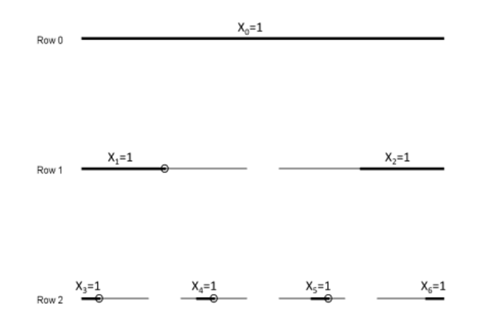

Figure 1: [0,1]에서 검은색으로 칠해진 부분이 1의 값을 갖는다.

**Proposition 2 (확률수렴의 기본적인 성질들)** $X_n \stackrel{P}{\rightarrow}X$, $Y_n \stackrel{P}{\rightarrow}Y$라고 하면

1. 만약 $X_n \stackrel{P}{\rightarrow}X'$이면 $P(X=X')=1$이다.
2. 모든 연속인 함수에 대해 $f(X_n)\stackrel{P}{\rightarrow}f(X)$이다. In fact, $f:\mathbb{R} \rightarrow \mathbb{R}$ need only be a Borel function whose set $D$ of discontinuities is such that $\{ \omega : X(\omega) \in D\}\in \mathcal{F}$ and $P(X\in D) = 0$.
3. $X_n \pm Y_n \stackrel{P}{\rightarrow} X \pm Y$.
4. $X_n Y_n \stackrel{P}{\rightarrow} XY$.
5. $\frac{X_n}{Y_n}\stackrel{P}{\rightarrow} \frac{X}{Y}$, provided that $P(Y=0)=0$.

*Proof.* 3의 +증명은 다음과 같다.
$$|X_n +Y_n - (X+Y)| \geq \epsilon \Rightarrow |X_n - X| \geq \frac{\epsilon}{2} \text{ or } |Y_n - Y| \geq \frac{\epsilon}{2} .$$
그러므로 Bonferroni inequality에 의해
$$\begin{align*}
P(|X_n +Y_n - (X+Y) | \geq \epsilon) &\leq P(|X_n - X|\geq \frac{\epsilon}{2} \cup |Y_n - Y|\geq \frac{\epsilon}{2})\\
&\leq P(|X_n - X| \geq \frac{\epsilon}{2}) + \leq P(|Y_n - Y| \geq \frac{\epsilon}{2})
\end{align*}$$

이다. 각가의 확률은 $n\rightarrow \infty$임에 따라 0으로 가므로 $P(|X_n + Y_n - (X+Y)|\geq \epsilon)\rightarrow 0$이고 따라서 $X_n + Y_n \stackrel{P}{\rightarrow} X+Y$가 된다.

## Lp 수렴(Convergence in Lp)

추정량 $\hat{\theta}_{n}$이 모수 $\theta$에 가까운 정도를 나타내는 또 다른 측도 중 하나는 **평균제곱오차(mean squared error, MSE)**, $E(\hat{\theta}_{n}-\theta)^{2}$이다. 이것은 두 개의 벡터 $\mathbf{x},\mathbf{y}$가 어느 정도 가까운지 나타내는 측도로 $\sum_{i=1}^{k}(x_{i}-y_{i})^{2}$을 나타내는 것과 동일한 아이디어이다. 그러나 두 벡터 사이의 거리를 나타내기 위해서 제곱근을 취하는 것차럼, $\hat{\theta}_{n}$과 $\theta$의 거리를 나타내기 위해 MSE에도 제곱근을 취한다. 이것이 $L^{p}$거리의 특수한 형태인 $L^{2}$거리를 유도한다.

**Definition 3 (Lp거리)** 만약 $X, Y$가 유한한 $p$차 모멘트 $(p>0)$을 갖는 확률변수들이라고 하면 $X$와 $Y$의 $L^{p}$거리는 $\{ E(|X-Y|^{p}) \}^{1/p}$로 정의한다.

$p\geq 1$일 때 $L^{p}$ 거리는 distance measure $d$의 조건들을 만족한다.

1. $d(X,Y)\geq 0$, with $d(X,Y)=0$ if and only if $X=Y$
2. $d(X,Y)=d(Y,X)$
3. $d(X,Z)\leq d(X,Y) + d(Y,Z)$ (follows easily from Minkowski’s inequality)

**Proposition 3 (Lp거리는 p에 대한 증가함수)** $X$와 $Y$ 사이의 $L_{p}$거리는 $p\geq 1$일 때 $p$에 대한 증가함수다.

*Proof.* $Z=|X-Y|^{p}$라고 두자. ($E(|X|)\leq \{ E(|X|^{p}) \}^{\frac{1}{p}}$)라는 성질에 의해 $1\leq p \leq q$인 $p,q$에 대해 $E(Z) \leq \{ E(Z^{\frac{q}{p}}) \}^{\frac{p}{q}}$가 된다. 즉 $E(Z)\leq \{ E(|X-Y|^{q}) \}^{\frac{p}{q}}$이다. 양변에 $p$제곱근을 취하면 $\{ E(|X-Y|^{p}) \}^{\frac{1}{p}}\leq \{ E(|X-Y|^{q}) \}^{\frac{1}{q}}$를 얻는다.

**Definition 4 (Lp수렴)** 확률변수들의 수열 $X_{1},X_{2},\ldots$가 $n\rightarrow 0$일 때 $E(|X_{n}-X|^{p})\rightarrow 0$을 만족할 경우 이 수열들이 $X$에 $L^{p}$ 수렴한다고 정의한다.

**Proposition 4 (Lq수렴은 Lp수렴을 유도)** $1\leq p \leq q$일 때 $L^{q}$ 수렴은 $L_{p}$ 수렴을 imply한다.

이것의 역은 성립하지 않는다. Stoyanov (2014) 14.5의 내용이다.

## 분포수렴(Convergence in distribution)

**분포수렴(Convergence in distribution)**은 분포함수의 관계를 다룬다는 점에서 확률변수들의 관계를 고려하는 앞 수렴들과는 다른 타입의 수렴이라고 할 수 있다. $X_{n}$의 분포함수 $F_{n}(x)$가 $X$의 분포함수 $F(x)$로 수렴할 때 우리는 $X_{n}$이 $X$에 대해 분포적으로 가까워진다고 말한다. 가장 단순한 예로 $X_{n}=1+\frac{1}{n}$이고 $X$는 1인 경우를 생각해 볼 수 있다. 이 때 $X_{n}$의 분포함수 $F_{n}(x)$는 다음과 같은 분포함수 $F(x)$로 가까워지는 것처럼 보인다.

$$\begin{equation}
F(x)=
\begin{cases}
0 & \text{if } x < 1 \\
1 & \text{if } x \geq 1
\end{cases}
\tag{3}
\end{equation}$$

그러나 $F_{n}(x)=P(X_{n}\leq x)$는

$$\begin{equation}
F_{n}(x)=
\begin{cases}
0 & \text{if } x < 1 + \frac{1}{n} \\
1 & \text{if } x \geq 1 \frac{1}{n}
\end{cases}
\tag{4}
\end{equation}$$

이며 이는

$$\begin{equation}
\begin{cases}
0 & \text{if } x \leq 1 \\
1 & \text{if } x > 1
\end{cases}
\end{equation}$$

로 수렴한다. 식 (3)과 식 (4)의 분포함수는 $x=1$에서 일치하지 않는다. 따라서, $F_{n}(x)$가 모든 $x$에서 $F(x)$로 수렴하는 것은 너무 강한 조건으로 보인다. 분포수렴을 정의할 때에는 앞선 예의 $x=1$처럼 불연속인 점들을 제외한 연속인 점들 $x$에서 $F_{n}(x) \rightarrow F(x)$가 되는 것으로 정의한다.

**Definition 5 (분포수렴)** $X_{n}, X$가 분포함수 $F_{n}(x), F(x)$를 갖는 확률변수들이라고 하자. 그러면 모든 연속인 점 $x$에 대해 $F_{n}(x)\rightarrow F(x)$일 경우 $X_{n}$이 $X$에 **분포수렴(converge in distribution)**한다고 정의하고 $X_{n}\stackrel{D}{\rightarrow} X$ 또는 $F_{n}\stackrel{D}{\rightarrow} F$로 쓴다.

**Example 8 (정규분포에서 나온 확률변수들의 분포수렴)** $X_{n}$이 평균 $\mu_{n}$이고 표준편차가 $\sigma_{n}$인 정규확률변수라고 하자. 그리고 $\mu_{n}\rightarrow\mu$이고 $\sigma_{n}\rightarrow\sigma >0$이다. 그러면 $P(X_{n}\leq x) = P\{\frac{X_{n}-\mu_{n}}{\sigma_{n}}\leq \frac{x-\mu_{n}}{\sigma_{n}}\}=\Phi\{ \frac{x-\mu_{n}}{\sigma_{n}} \}$이다. $\Phi$는 연속이고 $\frac{x-\mu_{n}}{\sigma_{n}}\rightarrow \frac{x-\mu}{\sigma}$이므로 $P(X_{n}\leq x) \rightarrow \Phi\frac{x-\mu}{\sigma}$이다. 즉 $X_{n}\stackrel{D}{\rightarrow}\mathcal{N}(\mu,\sigma^{2})$이다.

**Example 9 (Discrete uniform converging in distribution to continuous uniform)** Let $X_n$ have a discrete uniform distribution on the dyadic rationals of order $n$. That is,
$$P(X_n = \frac{i}{2^n})=\frac{1}{2^n}, \qquad{i=1,2,\ldots, 2^{n}}$$
이다. 우리는 $X\sim \text{Uniform}(0,1)$일 때 $X_n \stackrel{D}{\rightarrow}X$임을 보이고자 한다.

$x_d$를 dyadic rational of some order라고 하자. 즉 $x_d = \frac{i}{2^m}$ for some $m$ and some $i=1,\ldots, 2^{m}$이라고 놓는 것이다. 그러면 for $n\geq m$, $F_{n}(x_d) = P(X_n \leq x_d) = \frac{i}{2^{m}}=x_d$이다. 그러므로 $F_{n}(x_d) \rightarrow x_d$ for every dyadic rational number가 된다.

이제 $x$가 $(0,1)$ 사이의 임의의 수라고 하자. $x_1, x_2$를 $x_1 < x < x_2$인 arbitrary dyadic rational number라고 둔다. 그러면 $F_n(x_1) \leq F_{n}(x) \leq F_{n}(x_2)$이다. 따라서 $x_1 =\underline{\lim}F_{n}(x_1) \leq \underline{\lim}F_{n}(x)$가 된다. 비슷한 논리로 $\overline{\lim} F_{n}(x) \leq \overline{\lim} F_{n}(x_2) = x_2$가 된다. Because $x_1 < x$ and $x_2 > x$ are arbitrary dyadic rationals and we can find dyadic rationals arbitrarily close to $x$ (either less than or greater than), $x \leq \underline{\lim}F_{n}(x)$ and $\overline{\lim}F_{n}(x)$; i.e., $\underline{\lim}F_{n}(x)=\overline{\lim}F_{n}(x) = x$. Therefore, $F_{n}(x) \rightarrow x$. This being true for every $x\in(0,1), X_{n}\stackrel{D}{\rightarrow}X$, where $X\sim \text{uniform}(0,1)$.

위의 예제에서 쓰인 논리를 적용하면 다음을 보일 수 있다.

**Proposition 5 (약수렴의 동치조건: convergence on a dense set)** $X_{n}\stackrel{D}{\rightarrow}X$ if and only if $F_{n}(x) \rightarrow F(x)$ for all $x$ in a dense set $D$ of reals. 즉 만약 $y\in\mathbb{R}$이면 every nonempty interval containing $y$ contains at least one element of $D$.

**Exercise 1** 위 명제를 증명하시오.

*Remark.* 분포수렴은 약수렴이다. $X_n$들이 $X$에 가깝지 않더라도 분포만 비슷하게 가면 되기 때문이다. 심지어 $X_1,\ldots, X_n, \ldots$들이 같은 확률공간 안에 정의되지 않아도 상관없다. 그러나 우리가 배운 나머지 수렴들(거의 확실한 수렴, 확률수렴, Lp수렴 등)은 당연히 모두 다 같은 확률 공간 안에 있다는 전제 하에서 전개하는 것이다.

### Skorohod 표현 정리(Skorohod representation theorem)

Skorohod 표현 정리는 $X_n$이 $X$로 분포수렴 할 때에 common probability space에서 같은 marginal distribution을 갖으며 “거의 확실한 수렴을 하는” 새로운 확률변수의 수열들 $X_n '$와 $X'$를 찾아낼 수 있다는 것이다.

**Skorohod 표현 정리(Skorohod representation theorem)**이란 분포수렴이 확률변수의 다른 수열에서 거의 확실한 수렴을 보장해 주는 것이다.

**Theorem 1 (Skorohod 표현 정리)** 만약 $X_{n} \stackrel{D}{\rightarrow} X$라면 $(\Omega, \mathcal{F}, P)=((0,1),\mathcal{B}_{(0,1)}, \mu_{L})$에서 정의된 확률변수들 $Y_{n}$, $Y$가 존재해 $Y_{n}$가 $X_{n}$이랑 같은 분포를 갖고 $Y$는 $X$랑 같은 분포를 갖으며 $Y_{n}$는 $Y$에 거의 확실한 수렴을 한다.

*Proof.* 확률변수들 $Y_{n}(\omega) = F_{n}^{-1}(\omega)$ and $Y(\omega)= F^{-1}(\omega)$ defined on $((0,1),\mathcal{B}_{(0,1)}, \mu_{L})$ have respective distribution functions $F_n$ and $F$. The proof that $Y_{n}(\omega)\stackrel{\text{a.s.}}{\rightarrow}Y(\omega)$ for all but countably many $\omega$.

이를 수식으로 다시 쓰면, 우리가 $X_{n} \stackrel{D}{\rightarrow} X$ 임을 안다면 $Y_{n}\stackrel{D}{=}X_{n}$, $Y\stackrel{D}{=}X$ 이며 $Y_{n}\stackrel{a.s.}{\rightarrow}Y$인 $Y_{n}$과 $Y$이 존재해 준다는 것을 보장해 준다는 것이다.

**Proposition 6 (Alternative definition of convergence in distribution involving bound, continuous functions)** $X_{n}\stackrel{D}{\rightarrow} X \Leftrightarrow E\{ f(X_n) \} \rightarrow E\{f(X)\}$ for every bounded continous function.

**Proposition 7 (Alternative definition of convergence in distribution involving bound, continuous functions, 2)** If $X_n \stackrel{D}{\rightarrow}X$ and f is a continuous function, then $f(X_n) \stackrel{D}{\rightarrow}f(X)$. The same is true if the continuity assumption is replaced by the following weaker version: $f:\mathbb{R}\rightarrow \mathbb{R}$ is a Borel function whose set $D$ of discontinuities is a Borel set with $P(X\in D)=0$.

## 모호수렴(vague convergence)

모호수렴에 대해서는 (Gut 2014)의 5.8절에 자세히 설명되어 있다. 모호수렴과 분포수렴의 차이점은 전자의 경우 극한의 확률변수가 적절(proper)하지 않을 수 있다는 것이다. 여기서 부적절한(improper) 확률변수란 probability mass가 $\infty$ 또는 $-\infty$의 값을 가질수도 있음을 의미한다.

가장 단순한 형태의 부적절한 확률변수로 $\infty$ 또는 $-\infty$의 값을 0이 아닌 확률로 가질 수 있는 확률변수가 있겠다.

때때로 확률변수의 극한을 취했을 때 적절한 극한 확률변수가 존재하지 않을 수도 있지만 **유사분포함수(pseudo-distribution function)** 또는 **부확률분포(sub-probability distribution)** 등의 개념을 정의해 부적절한 확률변수들을 다룰 수 있다.

**Definition 6 (모호수렴)** 분포함수들의 수열 $\{F_{n}, n\geq 1 \}$은 모든 유한한 구간 $I = (a,b]\subset \mathbb{R}$, $a,b \in C(H)$일 때
$$F_{n}(I) \stackrel{n\rightarrow\infty}{\rightarrow}H(I)$$
를 만족할 경우 유사분포함수 $H$로 **모호수렴(coverges vaguely)**한다고 부른다. 이를 나타내기 위해 보통 $n\rightarrow\infty$일 때 $F_{n} \stackrel{v}{\rightarrow}H$라고 쓴다.

다시 반복해서 말하면 분포수렴의 경우 $H$의 total mass가 at most equal to 1인 경우다.

**Example 11 (모호수렴의 예(2))** $X_{n} \in U(-n,n),n\geq 1$이라고 하자. 그러면 분포함수는 다음과 같다.
$$F_{X_{n}}(x)=
\begin{cases}
0 & x<-n,\\
\frac{x+n}{2n} & -n \leq x < n,\\
1 & x\geq n.
\end{cases}$$
그리고 이것은 모든 $x\in \mathbb{R}$에 대해 $n\rightarrow\infty$일 때 다음으로 수렴한다.
$$H(x) \equiv \frac{1}{2}.$$
여기서도 또한 $H$는 부적절한 분포이다.

만약 $n\rightarrow\infty$일 때 $X_{n} \stackrel{d}{\rightarrow} X$일 경우 정의에 의해 $x\in C(F_{x})$이고 $n\rightarrow\infty$일 때 $F_{X_{n}}(x) \rightarrow F_{X}(x)$가 된다. 따라서 모든 bounded interval $I=(a,b]$, $a,b\in C(F_{X})$에 대해 $n\rightarrow\infty$일 때
$$F_{X_{n}}(I) = F_{X_{n}}(b) - F_{X_{n}}(a) \rightarrow F_{X}(b) - F_{X}(a) = F_{X}(I)$$
이다. 따라서 분포수렴은 항상 모호수렴이 된다. 즉 분포수렴은 모호수렴보다 더 강한 조건이다.

역이 성립할 필요충분조건은 분포함수의 꼬리가 uniformly small해야 한다는 조건과 필요충분이다. 이것은 엄격성과 연결된다.

### Helly의 선택정리(Helly’s selection principle)

엄격성을 언급하기 전에, Helly의 선택정리에 대해 먼저 살펴보자. (Gut 2014)의 내용을 따르면, **Helly의 선택정리(Helly’s selection principle)**는 어떤 부분수열에 대해서는 모호수렴이 항상 성립한다는 것이다.

**Theorem 2 (Helly의 선택정리)** $\{F_{n}, n\geq 1\}$이 분포함수들의 수열이라고 하자. 그러면 다음과 같이 감소하지 않는 부분수열 $\{n_{k} k\geq 1 \}$이 존재해 어떤 유사분포함수 $H$에 대해 $k\rightarrow\infty$일 때 다음을 만족한다.
$$F_{n_{k}} \stackrel{v}{\rightarrow} H .$$

### 엄격성(tightness)

이제 그러면 어떤 상황에서 이 부분수열의 수렴이 분포수렴이 될 수 있을지에 대해 생각해보아야 한다. 그에 대한 필요충분조건으로 분포함수들의 수열 $\{F_{n}\}$이 **엄격(tight)**한지 체크하면 된다. 여기서 tight의 정의는 (Proschan 2016)의 6.48을 따른다.

**Definition 7 (Tight sequence of distribution functions)** 분포함수들의 수열 $F_{1}(x), F_{2}(x),$가 모든 $\epsilon >0$에 대해 숫자 $M$이 존재해 $F_{n}(M) <\epsilon$이고 모든 $n$에 대해 $1-F_{n}(M) <\epsilon$일 경우 tight하다고 한다.

다음 정리는 (Gut 2014)의 5.8.3에 나오는 정리다.

**Theorem 3 (엄격성과 부분수열의 분포 수렴)** $\{F_{n}, n\geq 1\}$이 분포함수들의 수열이라고 하자. 모든 모호수렴하는 부분수열들이 분포수렴이 되기 위해서는(즉 극한이 적절성을 갖기 위해서는) 다음을 만족시키는 것이 필요충분조건이다.
$$\int_{|x|>a} dF_{n}(x) \rightarrow 0$$
as $a\rightarrow\infty$ uniformly in $n$.

## 수렴 사이들의 관계(Connections between modes of convergence)

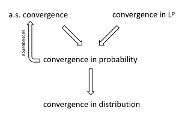

Figure 2: Connections between modes of convergences.

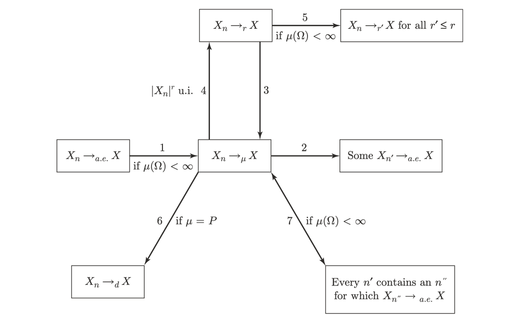

Figure 3: Connections between modes of convergences (2).

두 번째 그림은 Shorack (2017) 3장에서 가져왔다.

- 거의 확실한 수렴은 확률수렴을 보장, 그 역은 성립 안함
- $L_{p}$ 수렴은 확률수렴을 보장, 그 역은 성립 안함
- 확률수렴은 분포수렴을 보장, 그 역은 성립 안함

### Lp수렴과 확률수렴(Lp convergence and convergence in probability)

**Proposition 8 (Lp수렴은 확률수렴을 보장함)** If $X_n \rightarrow X$ in $L_{p}$, then $X_n \stackrel{p}{\rightarrow}X$.

*Proof.* Markov 부등식에 의해

$$\begin{align}
P(|X_n -X|\geq \epsilon) &= P(|X_n -X|^{p}\geq \epsilon^{p})\nonumber\\
&\leq E(|X_n - X|^{p})/\epsilon^{p} \rightarrow 0.
\end{align}$$

**Proposition 9 (Bias and variance both tending to 0 implies converges in probability)** An estimator $\hat{\theta}_{n}$ of $\theta$ whose bias and variance both tend to $0$ as $n\rightarrow \infty$ converges to $\theta$ in probability. In particular, the sample mean from a sample of $n$ i.i.d. observations with mean $\mu$ and finite variance converges in probability to $\mu$.

**Example 12 (확률수렴하나 Lp수렴하지 않는 예)** Let

$$X_{n}=
\begin{cases}
0 & \text{ with probability } 1- \frac{1}{n}\\
e^{n} & \text{ with probability } \frac{1}{n}
\end{cases}$$

Then $X_n \stackrel{p}{\rightarrow}0$ because, for $\epsilon \leq e^{n}$, $P(|X_n - 0 |\geq \epsilon) = \frac{1}{n} \rightarrow 0$. On the other hand, $E(|X_n - 0|^{p})= \frac{e^{np}}{n} \rightarrow\infty$ as $n\rightarrow \infty$ for every $p>0$.

### 확률수렴과 분포수렴(convergence in probability and convergence in distribution)

**Proposition 10 (확률수렴은 분포수렴을 보장)** If $X_n \stackrel{p}{\rightarrow}X$, then $X_n \stackrel{D}{\rightarrow}X$.

*Proof.* 이것을 증명하는 방법은 여러가지가 있지만, 여기서는 convergence in distribution의 정의만을 이용하는 방법을 생각해보기로 한다. $F_n$과 $F$를 $X_n$과 $X$의 분포함수라고 하고 $x$를 $F$의 continuity point라고 하자. $\epsilon$을 $x-\epsilon$, $x+\epsilon$ 또한 $F$의 continuity point가 되도록 하는 (충분히 작은) 수라고 하자.

$$\begin{align*}
\{X \leq x-\epsilon \}\cap \{ |X_n - X|<\epsilon\} &\Rightarrow X_n \leq x\\
P(X\leq x-\epsilon \cap |X_n - X|<\epsilon) &\leq F_{n}(x)\\
\underline{\lim}\{ P(X\leq x-\epsilon \cap |X_n - X|<\epsilon) \} &\leq \underline{\lim} F_{n}(x)\\
F(x-\epsilon) &\leq \underline{\lim}F_{n}(x).
\end{align*}$$

마지막 스텝은 $P(X\leq x-\epsilon \cap |X_n - X| <\epsilon)$ as $P(X\leq x-\epsilon) - P(X\leq x-\epsilon \cap |X_n - X| \geq \epsilon)$ and noting that $P(X\leq x-\epsilon \cap |X_n - X|\geq \epsilon) \leq P(|X_n - X|\geq \epsilon) \rightarrow 0$에서 유도된다.

위와 유사하게
$$\begin{align*}
X_{n} \leq x\cap |X_n - X| <\epsilon &\Rightarrow X\leq x + \epsilon\\
P(X_n \leq x) - P(X_n \leq x \cap |X_n - X| \geq \epsilon) &\leq F(x+\epsilon)\\
P(X_n \leq x) &\leq P(X_n \leq x \cap |X_n - X| \geq \epsilon) + F(x+\epsilon)\\
\overline{\lim} P(X_n \leq x) &\leq \overline{\lim}\{ P(X_n \leq x \cap |X_n - X| \geq \epsilon) + F(x+\epsilon) \}\\
\overline{\lim} F_{n}(x) \leq F(x+\epsilon).
\end{align*}$$

위 두 개의 논리로 $\underline{\lim} F_{n}(x) \geq F(x-\epsilon)$ 그리고 $\overline{\lim}F_{n}(x) \leq F(x+\epsilon)$임을 보였다. But $\epsilon$ was arbitrary subject only to $x-\epsilon$ and $x+\epsilon$ being continuity points of $F$. We can find a sequence $\epsilon_{m}\rightarrow 0$ such that $x-\epsilon_{m}$ and $x+ \epsilon_{m}$ are continuity points of $F$. Therefore, $\underline{\lim} F_{n}(x)= \overline{\lim}F_{n}(x) = F(x)$, proving that $F_n (x) \rightarrow F(x)$ for each continuity point of $x$ of $F$.

**Example 13 (분포수렴하지만 확률수렴하지 않는 예)** Let $X_1 , X_2, \ldots$ be i.i.d. Bernoulli $(\frac{1}{2})$ random variables. Then $X_n$ converges in distribution to $X_1$, but $X_n$ does not converge in probability to $X_1$ because $P(|X_n - X_1| > \frac{1}{2}) = P(X_n = 1, X_1 = 0) + P(X_n = 0, X_1 = 1) = \frac{1}{4} + \frac{1}{4} = \frac{1}{2}$.

### 거의 확실한 수렴과 확률수렴(Almost sure convergence and convergence in probability)

**Proposition 11 (Almost sure convergence implies convergence in probability)** If $X_n \stackrel{\text{a.s.}}{\rightarrow} X$, then $X_n \stackrel{p}{\rightarrow}X$.

*Proof.* For each $\epsilon > 0$, $P(|X_n - X|\geq \epsilon)\rightarrow 0$ as $n\rightarrow \infty$만 보이면 된다. $B_{n} = \{ |X_n - X|\geq \epsilon \}$ and $B = \{|X_n - X|\geq \epsilon \text{i.o.}\}$를 보이면 된다. The almost sure convergence of $X_n$ to $X$ implies that $P(B)=0$. Also, $B$ occurs if and only if $\omega \in \cup_{k=n}^{\infty}B_{k}$ for every $n=1,2,\ldots$. Equivalently,
$$B=\cap_{n=1}^{\infty}A_n ,\qquad{ where }A_n = \cup_{k=n}^{\infty}B_k$$
is a decreasing sequence of sets. It follows from the continuity property of probability that

$$\begin{align}
0 &= P(B) = B(\cap_{n=1}^{\infty}A_n)\nonumber\\
&= \lim_{n\rightarrow\infty}P(A_n) = \lim_{n\rightarrow\infty}P(\cup_{k=n}^{\infty}B_k).
\end{align}$$

We have shown that $P(\cup_{k=n}^{\infty}B_n)\rightarrow 0$ as $n\rightarrow \infty$. But $0\leq P(B_n) \leq P(\cup_{k=n}^{\infty}B_{k})$, so $P(B_n)\rightarrow 0$. Thus, $P(|X_n - X|\geq \epsilon) \rightarrow 0$ as $n\rightarrow 0$ as $n\rightarrow \infty$. Because this is true for every $\epsilon >0$, $X_n \stackrel{p}{\rightarrow} X$. 따라서 거의 확실한 수렴은 확률수렴을 내포한다.

## 보렐-칸텔리 따름정리(Borel-Cantelli lemma)

확률수렴이나 거의 확실한 수렴이 되지 않는 예로 6 를 소개한 적이 있다. 그러나 보렐-칸텔리 따름정리 1 는 이에 대한 새로운 예를 설명해준다. 더불어 확률수렴이 거의 확실한 수렴을 보장해주지는 않지만 적당히 subsequence를 잡았을 때 거의 확실한 수렴을 가지도록 만들 수 있다는 것도 보여준다.

**Lemma 1 (보렐-칸텔리 따름정리)** (Proschan 2016)

1. 만약 $A_{n}, n=1, 2, \ldots$가 infinite sequence of events이고 $\sum P(A_n) <\infty$이면 $P(A_n \text{i.o.})=0$이다. 이것은 $P$를 임의의 측도 $\mu$로 바꿔도 성립한다.
2. 만약 $A_{n}$들이 독립이고 $\sum_{n}P(A_n)=\infty$이면 $P(A_n \text{i.o.})=1$이다.

*Proof.* 1. 음이 아닌 확률변수 $X$를 $X(\omega)=\sum_{n}I(\omega \in A_n)$으로 정의하자. 그러면 $\omega \in A_n$ for infinitely many $n$ 과 동치조건은 $X(\omega)=\infty$인 것이다. 만약 $X=\infty$일 확률이 0이 아닐경우 당연히 $E(X)=\infty$가 되고 따라서
$$\infty = E(X)=E\Bigg\{ \sum_{n} I(A_n) \Bigg\}=\sum_{n}E\{I(A_n) \}= \sum_{n}P(A_n)$$

(interchange of expectation and summation is justified by the MCT because $\sum_{n=1}^{N}I(A_n)\uparrow \sum_{n=1}^{\infty}I(A_n)$.)

따라서 만약 $\sum_{n}P(A_n)<\infty$라면 $X$는 must be finite a.s.여야 하고 이것은 $P(A_n \text{i.o.})=0$임을 내포한다. 여기서 각 단계들은 $P$를 $\mu$로 바꿔도 성립한다.

2. 다음을 상기하자.
   $$P(A_n \text{ i.o.})= P(\cap_{N=1}^{\infty}\cup_{n=N}^{\infty}A_n) = P(\cap_{N=1}^{\infty}B_N),$$

이 때 $B_{N}=\cup_{n=N}^{\infty}A_{n}$ is a decreasing sequence of sets. 따라서 probability의 continuity property에 의해
$$P(\cap_{N=1}^{\infty}\cup_{n=N}^{\infty}A_n) = \lim_{N\rightarrow\infty}P(\cup_{n=N}^{\infty}A_n).$$

따라서 각각의 $N$에 대해 $P(\cup_{n=N}^{\infty}A_n)=1$을 보이는 것으로 충분하다.
$$P(\cup_{n=N}^{\infty}A_n)= 1- \prod_{n=N}^{\infty}(1-p_n),$$

where $p_n = P(A_n)$, we need only show that $\prod_{n=N}^{\infty}(1-p_n)=0$ 또는 $\sum_{n=N}^{\infty}\text{ln}(1-p_{n})=-\infty$를 보이면 된다. $f(x)=\text{ln}(1-x)$의 $x=0$에서의 테일러 급수를 이용하면
$$\text{ln}(1-x) = -x - (1-c)^{-2}x^{2}/2,$$

where $0 \leq c \leq x$가 된다. 따라서 $x>0$일 때 $\text{ln}(1-x) \leq -x$가 된다. 이것은 $\sum_{n=N}^{\infty}\text{ln}(1-p_n) \leq -\sum_{n=N}^{\infty}p_n = -\infty$가 된다.

다음은 (Stoyanov 2014) 책 4.2에 있는 보렐-칸텔리 따름정리 관련 내용이다.

**Example 14 (On the Borel-Cantelli lemma and its corollaries)** 1. FIrst Borel-Cantelli lemma의 역은 성립하지 않는다. $\Omega=[0,1]$, $\mathcal{F}=\mathcal{B}_{[0,1]}$이고 $P$를 르베그 측도라고 하자. 다음과 같은 event들의 수열 $A_n = [0,\frac{1}{n}], n=1,2,\ldots$를 생각해보자. 그러면 당연히 우리는 $A_n \downarrow, n\rightarrow \infty$일 것이고 $[A_n \text{ i.o.}]=\cap_{n=1}^{\infty}A_n =\emptyset$으로 $P[A_n \text{ i.o.}]=0$이 된다. 그러나 $\sum_{n=1}^{\infty}P(A_n) = \sum_{n=1}^{\infty}(\frac{1}{n})=\infty$이다. 따라서 FIrst Borel-Cantelli lemma의 역은 성립하지 않는다.

2. 위의 결과로 보았을 때 $\sum_{n=1}^{\infty}P(A_n)=\infty$가 $P[A_n]=1$을 보장해주지 않는다는 것을 알 수 있다. Second Borel-Cantelli lemma는 독립성 조건을 넣어야만 성립한다.

다음은 (Stoyanov 2014) 14.4에 있는 내용이다.

**Example 15 (On the Borel-Cantelli lemma and almost sure convergence)** Let $\{X_n , n \geq 1 \}$ be a sequence of random variables such that for each $\epsilon >0$,

$$\begin{equation}
\sum_{n=1}^{\infty}P[|X_n|>\epsilon] < \infty.
\tag{5}
\end{equation}$$

보렐-칸텔리 따름정리에 의하면 만약 $\{A_n, n \geq 1 \}$이 an arbitrary sequence of events and $\sum_{n=1}^{\infty}P(A_n)<\infty$, then $P[A_{n}, \text{ i.o.}]=0$. 이 따름정리와 식 (5) 에 따라 바로 $n\rightarrow \infty$일 때 $X_{n} \stackrel{\text{a.s.}}{\rightarrow}0$이 된다. 더불어 if for any sequence of numbers $\{\epsilon_n\}$ with $\epsilon_{n}\downarrow 0$일 때

$$\begin{equation}
\sum_{n=1}^{\infty}P[|X_n|> \epsilon_{n}]< \infty
\tag{6}
\end{equation}$$

인 경우에도 $n\rightarrow \infty$일 때 $X_{n} \stackrel{\text{a.s.}}{\rightarrow}0$이 된다. 이제 우리는 이 명제의 역이 참인지 아닌지 확인하고 싶다. 이러한 목적으로 $\Omega=[0,1]$, $\mathcal{F} = \mathcal{B}_{[0,1]}$ 그리고 르베그 측도 $P$인 확률공간 $(\Omega, \mathcal{F}, P)$를 고려해보자. 그리고 다음과 같은 확률변수들의 sequence $\{X_n, n\geq 1\}$
$$X_n = X_n(\omega)=
\begin{cases}
0 & \text{if } 0 \leq \omega \leq 1- \frac{1}{n}\\
1 & \text{if } 1- \frac{1}{n} < \omega \leq 1
\end{cases}$$
를 고려해보자. 명백히 $X_{n} \stackrel{\text{a.s.}}{\rightarrow}0$이 된다. 그러나, $\epsilon_{n}\downarrow 0$인 $\epsilon_{n}>0$에 대해 $P[|X_n|>\epsilon_n]=P[X_n =1]=\frac{1}{n}$ for sufficiently large $n$이다. 따라서
$$\sum_{n=1}^{\infty}P[|X_n|> \epsilon_{n}]= \infty$$
이 되어 조건 (6) 는 $X_n$이 0으로 almost sure convergence하기위한 충분조건이나 필요조건은 아니다.

다시 (Proschan 2016) 의 내용으로 돌아가서 다음의 예제를 살펴보자.

**Example 16 (Borel-Cantelli 따름정리를 이용해 만들 수 있는 거의 확실한 수렴과 확률수렴 관련 예제)** Let $X_n$ be independent Bernoulli random variables with $P(X_n = 1)= p_n = 1-P(X_n = 0)$, and suppose that $p_n = \frac{1}{n^2}$. 그러면 이 $X_n$은 거의 확실한 수렴을 하는가? 확률수렴을 하는가? 아니면 둘 다 하지 않는가? Note that the probability that $X_n = 1$ for infinitely many $n$ is $0$ by part 1 of the Borel-Cantelli lemma because $\sum_{n} P(X_n= 1) = \sum_{n}\frac{1}{n^2}<\infty$. This means that for each $\omega$ outside a set of probability $0$, there is an $N$ such that $X_n (\omega) =0$ for all $n\geq N$. For each such $\omega$, $X_n (\omega) \rightarrow 0$. Therefore, $X_n \stackrel{\text{a.s.}}{\rightarrow}0$.

이번엔 $p_n$이 $\frac{1}{n^2}$ 대신 $\frac{1}{n}$이라고 가정해보자. $\sum_{n}\frac{1}{n}=\infty$ and the events ${X_n }=1 $ are independent, part 2 of the Borel-Cantelli lemma implies that $P(X_n = 1 \text{ i.o. })=1$. 물론 $P(X_n - 0 \text{ i.o. })=1$이기도 하므로 $P(X_n = 0 \text{ i.o. } \cap X_n = 1\text{ i.o. })=1$이 된다. But each $\omega$ for which $X_n(\omega) = 0$ i.o. and $X_n(\omega)=1$ i.o. is an $\omega$ for which $X_n(\omega)$ does not converge. Therefore, if $p_n$ had been $\frac{1}{n}$, $X_n$ would not have converged almost surely to any random variable, although $X_n$ would still have converged to $0$ in probability.

그러나 $p_n =\frac{1}{n}$일 때 $X_n$이 $0$으로 거의 확실한 수렴을 하지 않더라도, subsequene $X_{n^2} = (X_1, X_4, X_9,\ldots)$는 part 1 of the Borel-Cantelli lemma에 의해 0으로 거의 확실한 수렴을 한다. 실제로 $\sum_{n}\frac{1}{n^2}<\infty$ 이므로 $P(|X_{n^2}-0| > 0 \text{ i.o. })=0$이 된다.

## Subsequence Arguments

사실 $X_n \stackrel{p}{\rightarrow}X$일 때 우리는 항상 $X_{n'} \stackrel{\text{a.s.}}{\rightarrow}X$인 subsequence를 찾을 수 있다.

**Definition 8 (Subsequence notation)** Suppose $(n_1, n_2, \ldots)$ is a sequence and $(i_1, i_2, \ldots)$ is a subsequence. That is, $i_1 = n_{k_1}, i_2 = n_{k_2},\ldots$ for some $k_1 <k_2< \ldots$. Letting $(N)$ denote $(n_1, n_2, \ldots)$ and $(I)$ denote $(i_1, i_2,\ldots)$, we write $(I) \subset (N)$. We use the term subsequence to refer to either $(I)$ or $x_i$ for $i\in (I)$.

Subsequence arguments can be helpful even in nonrandom settings, as the following result shows.

**Proposition 12 (Subsequence argument for convergence of numbers)** The sequence of numbers $x_n$ converges to $x$ if and only if every subsequence $(M) \subset (N)$ has a further subsequence $(J) \subset (M)$ such that $x_j \rightarrow x$ along $j\in (J)$.

*Proof.* It is clear that if $x_n \rightarrow x$, then every subsequence $x_m$, $m\in (M)$ also converges to $x$.

To prove the other direction, we use the contrapositive. If $x_n$ does not converge to $x$, then we can find an $\epsilon >0$ and a subsequence $(K)$ such that $|x_k - x|\geq \epsilon$ for all $k\in (K)$. But then clearly no subsequence $x_j$ $j\in (J) \subset (K)$ can converge to $x$. Therefore, if $x_n$ does not converge to $x$, then it cannot be true that every subsequence contains a further subsequence converging to $x$. By the contrapositive, this means that if every subsequence contains a further subsequence converging to $x$, then $x_n \rightarrow x$.

**Proposition 13 (Subsequence argument for convergence in probability or measure)** 1. $X_n \stackrel{p}{\rightarrow}X$ if and only if every subsequence $(M) \subset (N)$ has a further subsequence $(K) \subset (M)$ such that $X_{k}\stackrel{\text{a.s.}}{\rightarrow}X$ along $(K)$.

2. If $f_n$ and $f$ are functions on an arbitrary measure space $(\Omega, \mathcal{F}, \mu)$ and $f_n$ converges to $f$ in measure, then every subsequence $(M) \subset (N)$ contains a further subsequence $(K)\subset (M)$ such that $f_{k} \rightarrow f$ a.e. with respect to $\mu$ (although the reverse direction is not necessarily true).

*Proof.* Suppose first that $X_n \stackrel{p}{\rightarrow} X$, and let $(M) \subset (1,2,\ldots)$ be a subsequence. For a fixed number $k$, $\epsilon = \frac{1}{k}$ is a positive number and $P(|X_m - X|\geq \epsilon) \rightarrow 0$ as $m\rightarrow \infty$ along $(M)$. This means we can find $m_k \in (M)$ such that
$$P(|X_{m_k} - X| \geq \epsilon = \frac{1}{k}) \leq \frac{1}{k^2}.$$
Because $\sum_{k} \frac{1}{k^2} < \infty$, part 1 of the Borel-Cantelli lemma implies that $P(|X_{m_k} - X| \geq \frac{1}{k} \text{ i.o. in } k)=0$. But each $\omega$ for which $|X_{m_k}(\omega) - X(\omega)|\geq \frac{1}{k}$ for only finitely many $k$ is an $\omega$ for which $X_{m_k}(\omega)\rightarrow X(\omega)$ as $k\rightarrow\infty$. Therefore $X_{m_k}\stackrel{\text{a.s.}}{\rightarrow} X$ as $k\rightarrow\infty$. This shows that $X_{n}\stackrel{p}{\rightarrow} X$ implies that the subsequence $X_m$, $m\in M$ contains a further subsequence $X_{m_k}$ converging almost surely to $X$. The same argument works for $f_n$ converging in measure to $f$ with respect to a more general measure $\mu$.

**Proposition 14 (Subsequence argument for convergence in probability or measure)** 1. $X_n \stackrel{p}{\rightarrow} X$ if and only if every subsequence $(M)\subset (N)$ has a further subsequence $(K) \subset (M)$ such that $X_{k}\stackrel{\text{a.s.}}{\rightarrow}X$ along $(K)$.

2. If $f_n$ and $f$ are functions on an arbitrary measure space $(\Omega, \mathcal{F}, \mu)$ and $f_n$ converges to $f$ in measure, then every subsequence $(M)\subset (N)$ contains a further subsequence $(K) \subset (M)$ such that $f_k \rightarrow f$ a.e. with respect to $\mu$ (although the reverse direction is not necessarily true).

이러한 논리는 convergence in distribution에서도 적용된다.

**Proposition 15 (Subsequence argumnet for convergence in distribution)** $X_n \stackrel{D}{\rightarrow} X$ if and only if every subsequence $(M)\subset (N)$ has a further subsequence $(K) \subset (M)$ such that $X_{k}\stackrel{D}{\rightarrow} X$ along $(K)$.

Notice that is not sufficient for every subsequence to contain a further subsequence that converges in distribution; it must be the same distribution, as the following example shows.

**Example 17** Let $X_n$ be $\mathcal{N}(0,1)$ if $n$ is ood and $\mathcal{N}(0,2)$ is $n$ is even. Then every subsequence contains a further subsequence converging to a distribution function, but $X_n$ does not converge in distribution because $F_{2n+1} \stackrel{D}{\rightarrow}\mathcal{N}(0,1)$, but $F_{2n}\stackrel{D}{\rightarrow}\mathcal{N}(0,2)$.

위 예제에서 알 수 있듯이 different subsequence를 잡으면 수렴하는 distribution function도 달라진다. A very interesting question about a sequence of distribution functions is whether there is **any** subsequence that converges to a distribution function. The investigation of this question produces a very useful technique called the **diagonal technique** illustrated in the following theorem.

**Theorem 4 (Helley selection theorem)** If $F_1(x), F_2(x), \ldots$ is a sequence of distribution functions, there is a subsequence $(M)$ and an increasing, right-continuous function $F(x)$ such that $F_m (x) \rightarrow F(x)$ along (M) at all continuity points.

*Proof.* Let $\{r_i\}_{i}$ be an enumeration of the rational numbers. The $i$-th row of Table shows the set $\{F_1 (r_i), F_{2}(r_i), \ldots\}$, a bounded infinite set of numbers. Consider the first row. By the Bolzano-Weierstrass theorem, there is a limit point, so there is a subsequence $(M_1)$ such that $F_{m}(r_1) \rightarrow y_1 = F(r_1)$ as $m \rightarrow \infty$ along $(M_1)$. For instance, that subsequence might be the bolded elements $1,3,4,6,7,\ldots$ shown in row 1. In the second row, consider the bounded infinite set $(F_{m}(r_2))_{m\in(M_1)}.$ Again by the Bolzano-Weierstrass theorem, there must be a further subsequence $(M_2) \subset (M_1)$ such that $F_m(r_2)\rightarrow y_2 = F(r_2)$ as $m \rightarrow \infty$ along $(M_2)$. For instance, that subsequence of $1,3,4,6,7,\ldots$ might be $1,4,6,7,\ldots,$ the bolded sequence in row 2. Continuing in this fashion, we can find in row $i+1$ a subsequence $(M_{i+1})$ of $(M_i)$ such that $F_{m}(r_{i+1}) \rightarrow y_{i+1} = F(r_{i+1})$ as $m\rightarrow \infty$ along $(M_{i+1})$. Continuing this fashion, we can find in row $i+1$ a subsequence $(M_{i+1})$ of $(M_i)$ sucht that $F_{m}(r_{i+1})\rightarrow y_{i+1}= F(r_{i+1})$ as $m\rightarrow \infty$ along $(M_{i+1})$. Now define a subsequence $(M)$ by taking the first bolded element of row 1, the second bolded element of row 2, the third bolded element of row 3, etc. In table, this corresponds to the subsequence $(M) = (1,4,7,\ldots)$. Along this subsequence, $F_{m}(r_i)\rightarrow y_i = F(r_i)$ as $m\rightarrow \infty$ along $(M)$ for each rational $r_{i}$.

Now define $F(x)$ for irrational $x$ by $\inf \{ F(r), r>x, r \text{ rational} \}$. It is not difficult to show that $F$ is right continuous and increasing.

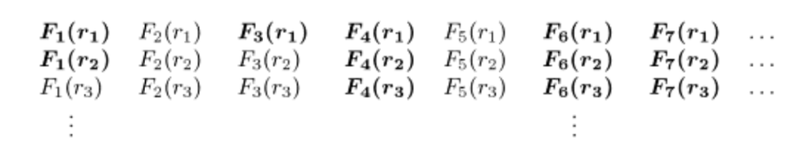

Figure 4: Helley selection theorem.

헬리의 선택 정리에서 알아두어야 할 점은 함수 $F(x)$는 분포함수의 세 가지 성질 중 두 가지만을 만족한다는 것이다. 부족한 부분은 $\lim_{x\rightarrow -\infty} F(x) = 0 = 1- \lim_{x\rightarrow \infty}F(x)$. The next example shows that this condition is not necessarily satisfied. 다음 예제를 살펴보자.

**Example 18 (Limit of d.f.s need not be a d.f)** Let
$$X_{n}=
\begin{cases}
-n & \text{w.p. } \frac{1}{2}\\
+n & \text{w.p. } \frac{1}{2}.
\end{cases}$$

Then for any subsequence $(M)$, the distribution function $F_m$ for $X_m$ satisfies $F_{m}(x) \rightarrow \frac{1}{2}$ as $m\rightarrow \infty$ along $(M)$. Therefore, there is no subsequence $(M)$ such that $F_m (x)$ converges to distribution function $F(x)$ as $m\rightarrow \infty$ along $(M)$.

앞서 헬리의 선택정리에서 얻은 $F(x)$가 분포함수가 되러면 **tightness**라는 추가 조건을 만족해야 한다.

**Definition 9 (분포함수들의 tight 수열)** The sequence of distribution functions $F_1(x), F_2(x),\ldots$ is said to be **tight** if for each $\epsilon >0$, there is a number $M$ such that $F_{n}(M)<\epsilon$ and $1-F_{n}(M)<\epsilon$ for all $n$.

앞선 예제의 분포함수는 tight하지 않은데 for any $M$, $1-F_{n}(M)=\frac{1}{2}$ for all $n>M$이기 때문이다.

**Proposition 16 (Connection between convergence in distribution and tightness)** The subsequence $F_{1}(x), F_{2}(x), \ldots$ has a further subsequence converging to a distribution function if and only if $F_1, F_2, \ldots$is tight.

**Corollary 1** If $F_{n}\stackrel{D}{\rightarrow}F$, then $F_n$ is tight.

마지막으로 $X_n$ converges to $X$ in some mannaer, then a continuous function $g(X_n)$ ought to converge to $g(X)$ in the same manner라는 Mann-Wald mapping 정리를 소개한다.

**Theorem 5 (Mann-Wald mapping theorem)** Suppose that $X_1, X_2, \ldots$ is a sequence of random variables and $f:\mathbb{R}\rightarrow \mathbb{R}$ is a Borel function whose set $D$ of discontinuities is such that $\{ \omega : X(\omega)\in D\}\in\mathcal{F}$ and $P(X\in D) = 0$. If $X_n$ converges to $X$ either

1. almost surely
2. in probability, or
3. in distribution,

Then $g(X_n)$ converges to $g(X)$ in the some sense.

## Convergence of moments: 일양적분가능성(uniform integrability)

$X_{n}$이 점근적으로 $\mathcal{N}(\mu_{n}, \sigma_{n}^{2})$에 수렴한다는 문장을 생각해보자. 즉 이 얘기는 $(X_{n}-\mu_{n})/\sigma_{n} \stackrel{D}{\rightarrow} \mathcal{N}(0,1)$이라는 말이다. 그러나 이것이 $E(X_{n})=\mu_{n}$이고 $\text{var}(X_{n})=\sigma_{n}^{2}$임을 의미하지는 않는다. 일반적으로 $X_{n} \stackrel{D}{\rightarrow} X$는 $E(X_{n}) \rightarrow E(X)$임을 의미하지 않는다.

**Example 19 (추정량은 무한대의 평균을 갖으나 확률변수의 극한은 유한한 평균을 갖는 예)** $\hat{p}_{n}$이 iid 베르누이 확률변수 $X_{1}, \ldots, X_{n}$로부터 나온 표본비(sample proportion)라고 하자. 그러면 CLT에 의해 $\hat{p}_{n}$은 점근적으로 평균 $p=E(X_{1})$이고 분산 $p(1-p)/n$인 정규분포를 따른다. 델타 방법(delta method)에 의해 $\text{ln}(\hat{p})$는 점근적으로 평균 $\ln(p)$, 분산 $(1-p)/(np)$인 정규분포를 따름을 안다. 그러면
$$Z_{n} = \frac{\text{ln}(\hat{p}_{n})-\text{ln}(p)}{\sqrt{(1-p)/(np)}} \stackrel{D}{\rightarrow} Z \sim \mathcal{N}(0,1)$$
임을 안다. 그러나 모든 $n$에 대해 $E\{\text{ln}(\hat{p}_{n}) \}=-\infty$인데, 이는 $\hat{p}_{n}$은 0이 될 확률이 양수이기 때문이다. 그러므로 $E(Z_{n})=-\infty$이나, $E(Z)=0$이다.

(Skrohod 정리를 이용한 추가적 설명 필요, Essential of Probability Theory for Statisticians 193-194쪽)

**Definition 10 (일양적분가능)** 만약 각 $\epsilon >0$에 대해
$$E\{ |X_{n}| I(|X_{n}|>A)\}<\epsilon \forall n$$
을 만족하는 $A$가 존재한다면 이 확률변수의 수열 $X_{n}$을 **일양적분가능(uniformly integrable, UI)**이라고 부른다. 또는
$$\lim_{A\rightarrow\infty}\sup_{n}E\{ |X_{n}| I(|X_{n}|>A)\}=0$$
을 만족하는 것으로 정의하기도 한다.

그렇다면 일양적분가능이 말하고자 하는 것은 무엇인가? $|X_{n}| I(|X_{n}|>A)$항부터 살펴보자. 이것은 $A$보다 작은 $|X_{n}|$ 값은 0이 되도록 조절하는 것이다. 다음 그림을 참고하자.

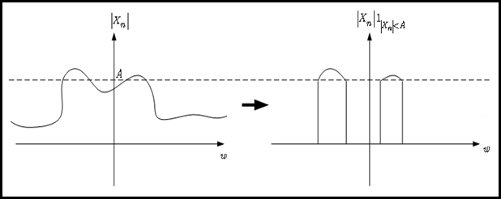

Figure 5: Case when function values bigger than A exist.

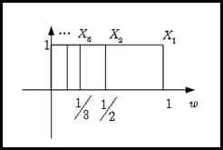

Figure 7: An example of sequence of random variables that is uniformly integrable.

위 예들로부터 얻을 수 있는 직관적 사실들은 다음과 같다. 만약 $X_{n}$의 평균 면적이 $n$이 커짐에 따라 무한대로 발산하면 그 확률변수의 수열은 항상 일양적분가능하지 않을 것이다. 한편

- 모든 유한한 수열을 항상 일양적분가능하다(왜냐하면 모든 고정된 $n$에 대해 $P(X_{n}>A)$는 $A$가 커짐에 따라 감소한다).
- 모든 유계(bounded)인 확률변수의 수열(반대로 유계가 아닌 경우를 생각해보면 $n$이 커짐에 따라 $X_{n}$은 어떤 확률로 점점 큰 값을 갖게 될 것이다)일양적분가능하다. 그러나 그 역은 성립하지 않는다.

마지막으로 유계가 아니나 일양적분가능한 확률변수의 수열의 예를 소개한다.

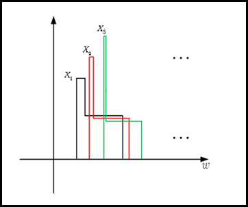

Figure 8: An example of sequence of random variables that is not bounded but uniformly integrable.

## Melding modes: Slutsky’s theorem

**Theorem 6 (Slutsky’s theorem)** $X_{n}\stackrel{D}{\rightarrow}X$, $A_{n}\stackrel{p}{\rightarrow}A$, 그리고 $B_{n}\stackrel{p}{\rightarrow}B$가 성립한다고 하자. 이 때 $A,B$는 상수들이다. 그러면 $A_n X_n + B_n \stackrel{D}{\rightarrow}AX+B$이다.

## 절대연속(absolute continuous)

확률변수 $X_{1}$, $X_{2}$가 있을 때 $X_{1}$이 $X_{2}$에 대해 **절대연속(absolute continuous)**하다는 것은(정확히 얘기하면 $X_{1}$의 분포가 $X_{2}$의 분포에 대해 절대연속이다) 적당한 집합 $F$에 대해 $P(X_{2}\in F)=0$이 $P(X_{1}\in F)=0$임을 내포하는 것과 동치이다.

## 대수의 법칙(law of large numbers)

**Proposition 17 (대수의 약법칙과 대수의 강법칙)** **대수의 약법칙(weak law of large numbers, WLLN)**은 $\bar{X}_{n}$이 $\mu$에 확률수렴하는 것이고, **대수의 강법칙(strong law of large numbers, SLLN)**은 $\bar{X}_{n}$이 $\mu$에 거의 확실한 수렴을 하는 것이다.

## 확률변수들의 함수의 수렴(convergence of functions of random variables)

연속 사상 정리는 (Gut 2014)의 서술을 따른다.

**Theorem 7 (연속 사상 정리)** $X_{1}, X_{2},\ldots$가 확률변수들이라고 하고 $n\rightarrow \infty$일 때 $X_{n}\stackrel{d}{\rightarrow}$라고 하자. 만약 (실수 값을 갖는) 함수 $g$가 존재해 이것이 연속이라면, $n\rightarrow \infty$일 때 $g(X_{n})\stackrel{d}{\rightarrow}$이다.

Gut, Allan. 2014. *Probability: A Graduate Course*. 2nd ed. Springer New York. https://www.ebook.de/de/product/23277813/allan_gut_probability_a_graduate_course.html.

Proschan, Michael A. 2016. *Essentials of Probability Theory for Statisticians*. CRC Press. https://www.ebook.de/de/product/25453130/michael_a_proschan_essentials_of_probability_theory_for_statisticians.html.

Shorack, Galen R. 2017. *Probability for Statisticians*. 2nd ed. Springer International Publishing. https://www.ebook.de/de/product/28189528/galen_r_shorack_probability_for_statisticians.html.

Stoyanov, Jordan M. 2014. *Counterexamples in Probability: Third Edition*. 3rd ed. DOVER PUBN INC. https://www.ebook.de/de/product/19654789/jordan_m_stoyanov_counterexamples_in_probability_third_edition.html.